# Analisis del incremento de poblacion por provincias, años 2001-2021

Guillermo

2024-04-23

### PASO 0

PARTIMOS DE LOS DATOS OBTENIDOS EN LA LIMPIEZA DE DATOS. (https://github.com/fenris123/population-data-cleaning-using-R)

INSTALACION DE LIBRERIAS NECESARIAS

DESACTIVACION DE LA NOTACION CIENTIFICA EN LOS EJES POR DEFECTO.

```r
### install.packages("ggplot2")
### install.packages("sf")

library(ggplot2)
library(sf)
options(scipen = 999)
```

### PASO 1

CARGAR DATOS DEL EJERCICIO ANTERIOR (ver readme)

Ademas vamos a crear una nueva columna que nos muestre el incremento o decrecimiento de la población en ese tiempo. Adicionalmente podria hacerse con los datos desagregados por sexo tambien.

```r
tabla_datos <- read.csv("C:/espacior/tabla_combinada.csv")

tabla_datos$IncrementoPOB <- tabla_datos$POB21 - tabla_datos$POB01
```

### PASO 2

Vamos a hacer un analisis inicial de los datos.

```r
summary (tabla_datos)
```

```
##      CPRO01       PROVINCIA             CMUN01         NOMBRE
##  Min.   : 1.00   Length:7168        Min.   :  1.0   Length:7168
##  1st Qu.:13.00   Class :character   1st Qu.: 43.0   Class :character
##  Median :25.00   Mode  :character   Median : 94.0   Mode  :character
##  Mean   :26.67                      Mean   :128.7
##  3rd Qu.:41.00                      3rd Qu.:178.0
##  Max.   :52.00                      Max.   :914.0
##      POB01             HOMBRES01           MUJERES01           CPRO21
##  Min.   :      5.0   Min.   :      4.0   Min.   :      1   Min.   : 1.00
##  1st Qu.:    190.0   1st Qu.:     99.8   1st Qu.:     90   1st Qu.:13.00
##  Median :    567.5   Median :    291.0   Median :    277   Median :25.00
##  Mean   :   5040.2   Mean   :   2471.1   Mean   :   2569   Mean   :26.67
##  3rd Qu.:   2160.2   3rd Qu.:   1089.0   3rd Qu.:   1070   3rd Qu.:41.00
##  Max.   :2957058.0   Max.   :1380788.0   Max.   :1576270   Max.   :52.00
##      CMUN21          POB21           HOMBRES21           MUJERES21
##  Min.   :  1.0   Min.   :      3   Min.   :      3.0   Min.   :      0
##  1st Qu.: 43.0   1st Qu.:    151   1st Qu.:     83.0   1st Qu.:     68
##  Median : 94.0   Median :    513   Median :    269.5   Median :    242
##  Mean   :128.7   Mean   :   5799   Mean   :   2841.6   Mean   :   2957
##  3rd Qu.:178.0   3rd Qu.:   2383   3rd Qu.:   1203.5   3rd Qu.:   1169
##  Max.   :914.0   Max.   :3305408   Max.   :1540894.0   Max.   :1764514
##  IncrementoPOB
##  Min.   :-23727.0
##  1st Qu.:  -111.0
##  Median :   -29.0
##  Mean   :   758.8
##  3rd Qu.:   117.0
##  Max.   :348350.0
```

Como nos interesa sobre todo la variacion de la población, vamos a hacer una representacion visual de la misma.

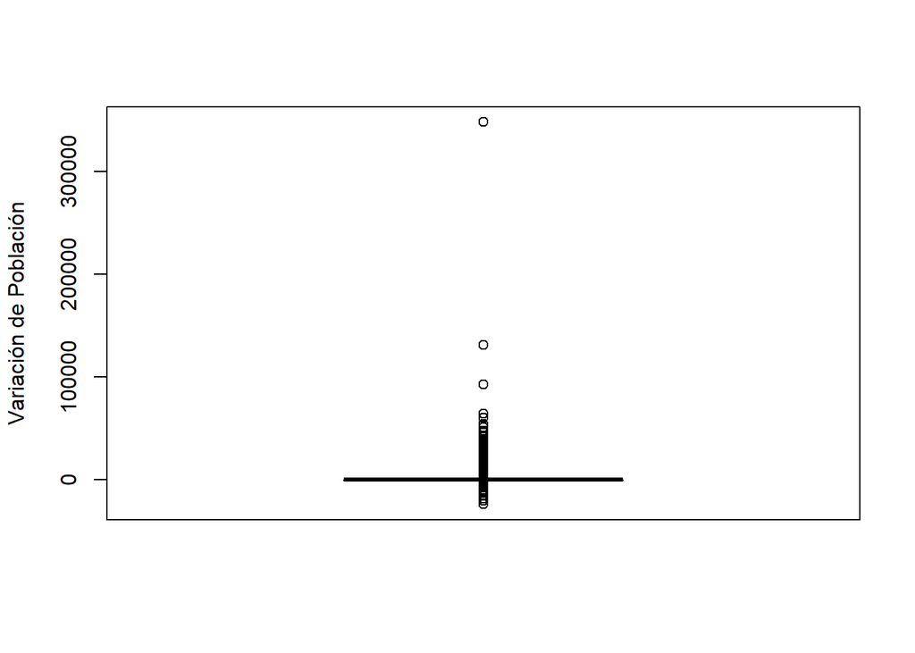

```r
boxplot(tabla_datos$IncrementoPOB, ylab = "Variación de Población")
```

En este analisis nos encontramos con que la función boxplot considera demasiados datos como outliers. Vamos a comprobarlo haciendo que elimine lo que considera outlier.

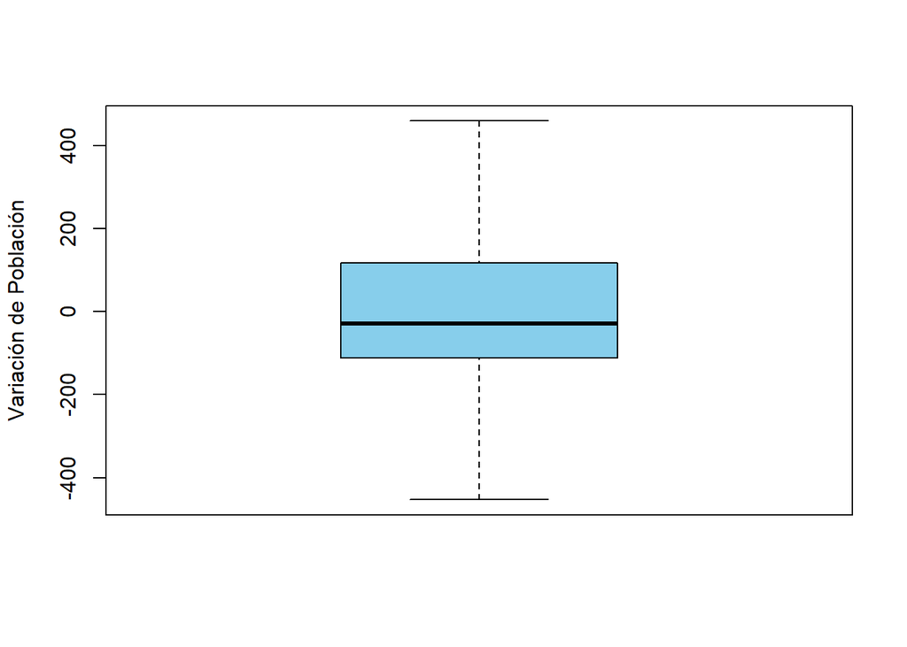

```r
boxplot(tabla_datos$IncrementoPOB, ylab = "Variación de Población", col = "skyblue", border = "black", outline = FALSE)
```

Notese la enorme diferencia en el eje Y. Esto nos debe llevar a hacer un diagrama de densidad o un histograma

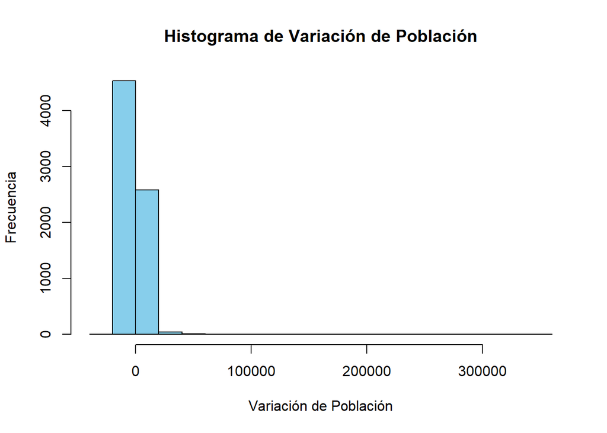

```r
hist(tabla_datos$IncrementoPOB, col = "skyblue", border = "black", xlab = "Variación de Población", ylab = "Frecuencia", main = "Histograma de Variación de Población")
```

Repetimos para la densidad:

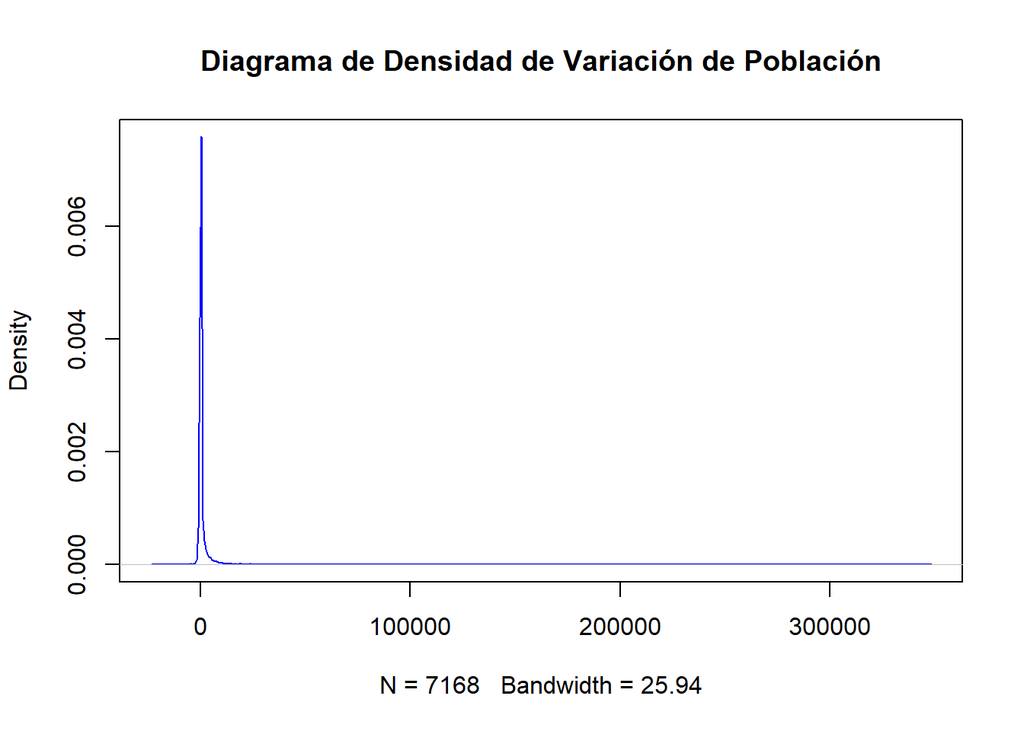

```r
densidad <- density(tabla_datos$IncrementoPOB)

plot(densidad, col = "blue", main = "Diagrama de Densidad de Variación de Población")
```

Con todo esto, ilustramos lo que ya nos decia el analisis inicial hecho con “summary”: La inmensa mayoria de los municipios tienen una variacion de muy pocos cientos de personas arriba o abajo.

Mas adelante veremos que porcentaje es ese del total (No es lo mismo 100 personas mas para un pueblo de 1000 habitantes que para Madrid) pero antes vamos a ver exactamente que 10 Municipios crecieron mas, y que 10 municipios crecieron menos.

Para ello crearemos una nueva tabla, solo con nombre, provincia, y variacion de poblacion. La ordenaremos por su variacion de poblacion, y veremos el cambio de población de los 10 que mas ganan.

```r
tabla_corta <- tabla_datos[, c("NOMBRE", "PROVINCIA", "IncrementoPOB")]
tabla_corta <- tabla_corta[order(-tabla_datos$IncrementoPOB), ]
head(tabla_corta, 10)
```

```
##                 NOMBRE        PROVINCIA IncrementoPOB
## 3792            Madrid           Madrid        348350
## 785          Barcelona        Barcelona        131407
## 4013            Murcia           Murcia         93160
## 7165          Zaragoza         Zaragoza         64325
## 3831 Rivas-Vaciamadrid           Madrid         60697
## 3813             Parla           Madrid         54532
## 133   Alicante/Alacant Alicante/Alacant         54061
## 310    Roquetas de Mar          Almería         51155
## 1017          Terrassa        Barcelona         48255
## 3864         Valdemoro           Madrid         46601
```

Repetimos para los 10 que menos ganan (o mas pierden).

```r
tail(tabla_corta, 10)
```

```
##          NOMBRE  PROVINCIA IncrementoPOB
## 4354    Langreo   Asturias         -9717
## 2483    Granada    Granada        -11566
## 4359     Mieres   Asturias        -11900
## 5101  Santander  Cantabria        -13010
## 4891  Salamanca  Salamanca        -15254
## 3349       León       León        -15333
## 1947     Ferrol Coruña (A)        -15562
## 5396    Sevilla    Sevilla        -18286
## 6502 Valladolid Valladolid        -20518
## 1620      Cádiz      Cádiz        -23727
```

### PASO 3

Vamos a estudiar la variacion porcentual de la poblacion en cada municipio.

Muchos de los pasos seran similares a los realizados anteriormente, en esos casos no se explicara todo.

Lo primero sera crear una tabla con la variacion porcentual.

```r
var_porcentual <- ((tabla_datos$POB21 - tabla_datos$POB01) / tabla_datos$POB01) * 100

tabla_datos$var_porcentual <- round(var_porcentual,1)
```

Ahora haremos un “summary” solo de la nueva columna (las demas ya las conocemos)

```r
summary (tabla_datos$var_porcentual)
```

```
##      Min.   1st Qu.    Median      Mean   3rd Qu.      Max.
##  -82.1000  -28.8000  -11.4000    0.1395   13.2250 2659.5000
```

La variacion es enorme, desde el -82%, hasta el 2659 %. No obstante los datos se acumulan entre el -30 y el 15% aprox.

Vamos a representarlo en un histograma y un diagrama de densidad como se hizo previamente con la variacion total.

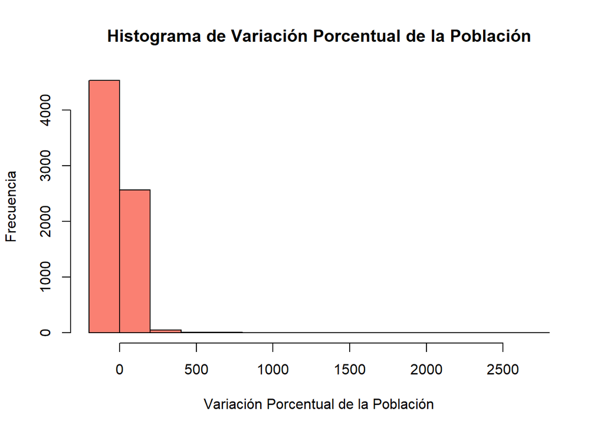

```r
hist(tabla_datos$var_porcentual, col = "salmon", border = "black", xlab = "Variación Porcentual de la Población", ylab = "Frecuencia", main = "Histograma de Variación Porcentual de la Población")
```

Repetimos con la densidad

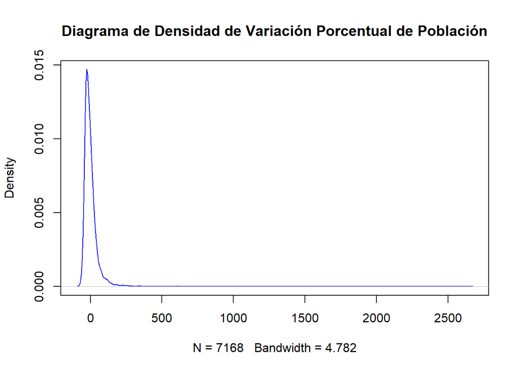

```r
densidad <- density(tabla_datos$var_porcentual)    #REQUIERE QUE SEA NUMERIC Y NO ROUND

plot(densidad, col = "blue", main = "Diagrama de Densidad de Variación Porcentual de Población")
```

En una presentacion real ajustariamos un poco mas las etiquetas en el eje X e Y. (“density” lo pondriamos en español, etc).

Por lo demas, vamos examinar los 10 municipios que mas poblacion ganan porcentualmente.

Lo haremos en una tabla corta diferente a la anterior

```r
tabla_corta_porcent<- tabla_datos[, c("NOMBRE", "PROVINCIA", "var_porcentual")]
tabla_corta_porcent <- tabla_corta_porcent[order(-tabla_datos$var_porcentual), ]
head(tabla_corta_porcent, 10)
```

```
##                       NOMBRE   PROVINCIA var_porcentual
## 2827                   Yebes Guadalajara         2659.5
## 2745                    Quer Guadalajara          958.6
## 5949               Barcience      Toledo          778.5
## 5214    Hontanares de Eresma     Segovia          768.2
## 2736                    Pioz Guadalajara          647.5
## 3735           Arroyomolinos      Madrid          616.7
## 2664               Galápagos Guadalajara          610.5
## 6977        Cuarte de Huerva    Zaragoza          605.2
## 4738 Castellanos de Moriscos   Salamanca          580.1
## 3823         Pozuelo del Rey      Madrid          557.5
```

Repetimos para los que mas poblacion pierden porcentualmente.

```r
tail(tabla_corta_porcent, 10)
```

```
##                        NOMBRE   PROVINCIA var_porcentual
## 5270 Riaguas de San Bartolomé     Segovia          -71.4
## 2627     Cendejas de la Torre Guadalajara          -71.8
## 2733               Peralveche Guadalajara          -71.8
## 4845              Navamorales   Salamanca          -72.2
## 5463                 Cigudosa       Soria          -72.6
## 2642              Congostrina Guadalajara          -73.3
## 2594                 Arbeteta Guadalajara          -73.7
## 5151                Bercimuel     Segovia          -78.7
## 2588                    Angón Guadalajara          -80.5
## 2015     Arandilla del Arroyo      Cuenca          -82.1
```

Vamos a crear una tabla con 2 columnas: los 10 municipios que mas poblacion pierden, y los 10 que mas porcentaje pierden.

```r
pierden_mas_poblacion<-tail(tabla_corta$NOMBRE, 10)
pierden_mas_porcentaje<-tail(tabla_corta_porcent$NOMBRE, 10)

poblacion_perdida <- cbind (pierden_mas_poblacion, pierden_mas_porcentaje )
print (poblacion_perdida)
```

```
##       pierden_mas_poblacion pierden_mas_porcentaje
##  [1,] "Langreo"             "Riaguas de San Bartolomé"
##  [2,] "Granada"             "Cendejas de la Torre"
##  [3,] "Mieres"              "Peralveche"
##  [4,] "Santander"           "Navamorales"
##  [5,] "Salamanca"           "Cigudosa"
##  [6,] "León"                "Congostrina"
##  [7,] "Ferrol"              "Arbeteta"
##  [8,] "Sevilla"             "Bercimuel"
##  [9,] "Valladolid"          "Angón"
## [10,] "Cádiz"               "Arandilla del Arroyo"
```

Como vemos no coinciden.

Podriamos si quisieramos repetirlo para los que mas ganan.

### PASO 4

Vamos a intentar realizar una representacion grafica de la variacion de la poblacion por provincias sobre un mapa.

En un caso real podriamos y deberiamos repetir el analisis anterior pero por provincias. No vamos a hacerlo.

Solo vamos a representar visualmente la variacion por provincias sobre un mapa.

Lo primero sera hacer una nueva tabla y quedarnos solo con las columnas de Provincia, Poblacion en el año 01, poblacion en el año 21, variacion de poblacion y luego sumar los diferentes datos de cada provincia que pertenecian a los diferentes municipios para obtener el total de la provincia, que sera el dato que nos quedaremos.

```r
tabla_provincias <- tabla_datos[, c("PROVINCIA","POB01", "POB21","IncrementoPOB")]

tabla_provincias <- aggregate(. ~ PROVINCIA, data = tabla_provincias, FUN = sum)

summary (tabla_provincias)
```

```
##   PROVINCIA             POB01             POB21         IncrementoPOB
##  Length:51          Min.   :  68789   Min.   :  83517   Min.   : -62907.0
##  Class :character   1st Qu.: 272674   1st Qu.: 275914   1st Qu.:    -78.5
##  Mode  :character   Median : 472599   Median : 549454   Median :  30480.0
##                     Mean   : 708400   Mean   : 815043   Mean   : 106642.7
##                     3rd Qu.: 789351   3rd Qu.: 848822   3rd Qu.: 158733.5
##                     Max.   :5275348   Max.   :6585594   Max.   :1310246.0
```

Vemos que nos da 51 provincias. Revisando la tabla vemos que esto se debe a que no tenemos los datos de la Rioja.

#### VEASE EL README SOBRE LOS DATOS CON LOS QUE ESTAMOS TRABAJANDO, Y QUE EN LA LIMPIEZA SE TOMARON DECISIONES POR MOTIVOS DE SIMPLICIDAD Y DIDACTICA QUE EN UN CASO REAL PODRIAN AFECTAR Y SERIAN DISCUTIBLES. AQUI TENEMOS UN EJEMPLO.

En principio, no meteremos datos extra para La Rioja. La representacion deberia dejarla en blanco.

Por lo demas, proseguiremos cargando el archivo shp.

```r
mapa <- st_read("C:/espacior/mapa/provincias/shapefiles_provincias_espana.shp")
```

Comprobamos si la nomenclatura de las provincias coincide en el mapa y en nuestra tabla.

```r
diferencias<-setdiff(tabla_provincias$PROVINCIA, mapa$texto)
print (diferencias)
```

```
##  [1] "Álava"              "Alicante/Alacant"   "Almería"
##  [4] "Ávila"              "Balears (Illes)"    "Cáceres"
##  [7] "Cádiz"              "Castellón/Castelló" "Córdoba"
## [10] "Coruña (A)"         "Girona"             "Guipúzcoa"
## [13] "Jaén"               "León"               "Málaga"
## [16] "Ourense"            "Palmas (Las)"       "Valencia/València"
```

Observamos que hay 18 diferencias.

No obstante observamos que el mapa también nombra las provincias por su código.

En los datos iniciales teniamos ese código, asi que iniciaremos el proceso de nuevo, añadiendo la columna CODIGO.

PODRIAMOS HABER OBVIADO ESTO Y PONER SOLO EL ANALISIS “BONITO”, BORRANDO EL SCRIPT Y AÑADIENDO LA COLUMNA CODIGO DESDE UN INICIO, PERO QUEREMOS REFLEJAR LO QUE PUEDE SUCEDER EN LA REALIDAD. QUE NO LO VEAMOS EN UN INICIO Y HAYA QUE MODIFICAR LO YA HECHO.

Repetiremos los pasos dados, incluyendo la nueva columna, y con pequeñas variaciones (Sumaremos la población de cada municipio, pero obviamente no sumaremos el código, p ej.)

```r
tabla_provincias <- tabla_datos[, c("PROVINCIA","POB01", "POB21","IncrementoPOB","CPRO01")]

tabla_provincias <-  aggregate(. ~ PROVINCIA + CPRO01, data = tabla_provincias, FUN = sum)


summary (tabla_provincias)
```

```
##   PROVINCIA             CPRO01          POB01             POB21
##  Length:51          Min.   : 1.00   Min.   :  68789   Min.   :  83517
##  Class :character   1st Qu.:13.50   1st Qu.: 272674   1st Qu.: 275914
##  Mode  :character   Median :27.00   Median : 472599   Median : 549454
##                     Mean   :26.51   Mean   : 708400   Mean   : 815043
##                     3rd Qu.:39.50   3rd Qu.: 789351   3rd Qu.: 848822
##                     Max.   :52.00   Max.   :5275348   Max.   :6585594
##  IncrementoPOB
##  Min.   : -62907.0
##  1st Qu.:    -78.5
##  Median :  30480.0
##  Mean   : 106642.7
##  3rd Qu.: 158733.5
##  Max.   :1310246.0
```

Vamos a ponerle un nombre mas simple y descriptivo a esa columna. Usaremos el mismo de la tabla mapa, lo que facilitara aun mas su comprensión.

```r
colnames(tabla_provincias)[colnames(tabla_provincias) == "CPRO01"] <- "codigo"
```

Para representar los datos en el mapa, debemos unir la tabla con los datos, con la tabla que contiene los datos del archivo el shp.

lo haremos uniendo las filas con el mismo codigo de provincia en cada tabla.

```r
colnames(tabla_provincias)[colnames(tabla_provincias) == "CPRO01"] <- "codigo"
tabla_grafico <- merge(mapa, tabla_provincias, by.x = "codigo", by.y = "codigo", all.x = TRUE)

View (tabla_grafico)  # Esto lo podemos realizar en R studio solo como comprobacion, sin ponerlo en el codigo final.                       # Lo mostramos por que vemos un problema que vamos a corregir
```

```r
mapa$codigo<- as.numeric(mapa$codigo)
mapa$codigo[1:9] <-c(1:9)
tabla_grafico <- merge(mapa, tabla_provincias, by.x = "codigo", by.y = "codigo", all.x = TRUE)
```

Ahora vamos con la representacion gráfica.

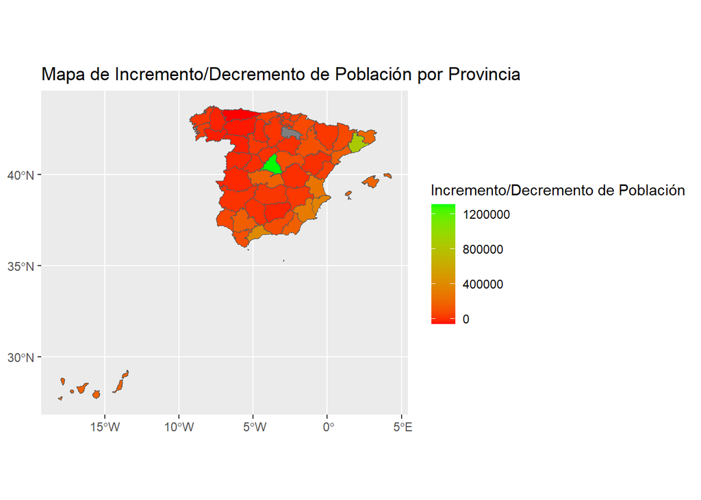

```r
ggplot() +
  geom_sf(data = tabla_grafico, aes(fill = IncrementoPOB)) +
  scale_fill_gradient(name = "Incremento/Decremento de Población",
                      low = "red", high = "green") +
  labs(title = "Mapa de Incremento/Decremento de Población por Provincia")
```

Lo anterior ya seria correcto, pero vamos a jugar un poco para hacer cosas como cambiarle el color para lograr un mejor contraste.

Morado y naranja son los colores que dan menos problemas de vision a los daltonicos

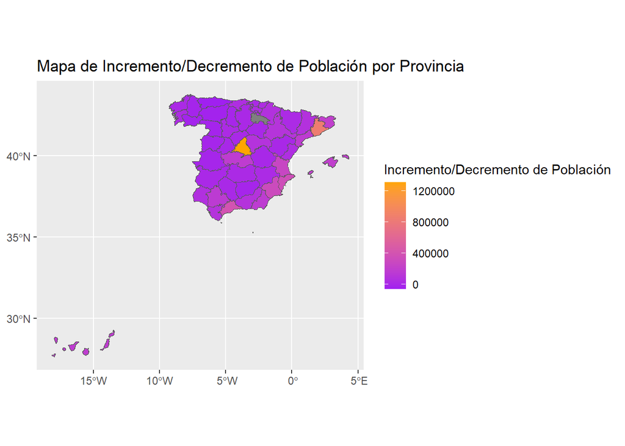

```r
ggplot() +
  geom_sf(data = tabla_grafico, aes(fill = IncrementoPOB)) +
  scale_fill_gradient(name = "Incremento/Decremento de Población",
                      low = "purple", high = "orange") +
  labs(title = "Mapa de Incremento/Decremento de Población por Provincia")
```

Con estos colores ademas de dar menos problemas a los daltonicos, el gradiente se diferencia mejor. (Puede ser opinion personal)

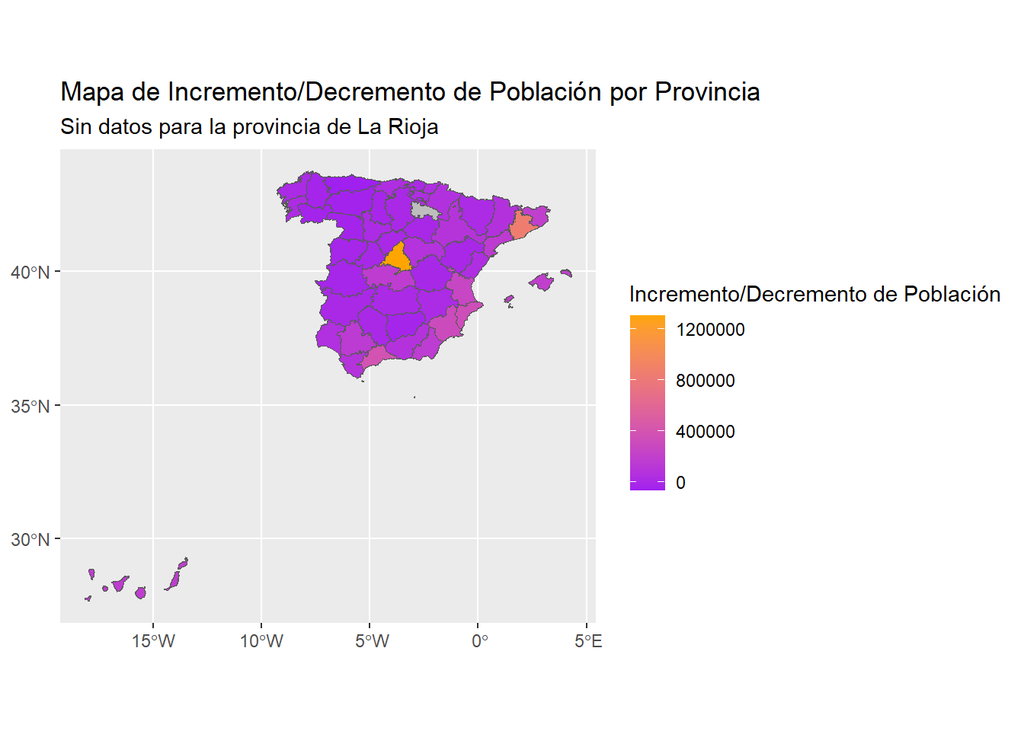

```r
ggplot() +
  geom_sf(data = tabla_grafico, aes(fill = IncrementoPOB)) +
  scale_fill_gradient(name = "Incremento/Decremento de Población",
                      low = "purple", high = "orange",
                      na.value = "grey") +
  labs(title = "Mapa de Incremento/Decremento de Población por Provincia",
       subtitle = "Sin datos para la provincia de La Rioja") +
  guides(fill = guide_colorbar(title = "Incremento/Decremento de Población"))
```

La representacion gráfica puede variarse y añadirle todos los detalles que se quieran, pero creemos que ya es suficiente.

Tras todo esto, podriamos usar algun comando como ggsave para guardar el gráfico. Tiene sentido si se trabajase con datos muy variables y se quisiese automatizar algo, etc.

Pero para un analisis simple como este la realidad es que basta con click derecho sobre el gráfico, y “guardar como”.